# Diagnostics and Model Comparison

mixedFlowR tutorial series

# 1 Purpose

Model comparison should follow model diagnosis, not replace it. This vignette develops a structured workflow for convergence, singularity, residual patterns, simulation diagnostics, influence, likelihood-based comparisons, small-sample tests, and parametric-bootstrap comparisons.

# 2 1. Learning objectives

You will learn to:

- interpret convergence and singularity diagnostics;
- inspect residual data before inference;
- use `DHARMa` simulation diagnostics for supported GLMMs;
- conduct grouped influence analysis;
- compare candidate models using information criteria without automatic selection;
- perform fixed-effect LRTs under ML;
- use Kenward-Roger and parametric-bootstrap comparisons for suitable LMMs;
- understand why a valid comparison depends on the estimand and fitting method.

# 3 2. Diagnose a Gaussian LMM

```r
library(mixedFlowR)
z <- mixed_data("longitudinal")
```

```r
if (requireNamespace("lme4", quietly = TRUE)) {
  fit <- mixed_fit(
    height ~ treatment * time + (time | subject),
    data = z
  )
}
```

```r
if (exists("fit")) {
  diag <- mixed_diagnose(fit)
  diag
}
```

```
#> $engine
#> [1] "lme4"
#>
#> $converged
#> [1] TRUE
#>
#> $convergence_messages
#> character(0)
#>
#> $singular
#> [1] FALSE
#>
#> $residuals
#>       fitted     residual
#> 1   16.36871  0.905836525
```

[output cut: 192 more lines]

The diagnostic object contains convergence status, messages, singularity where supported, residual data, variance summaries, and optional simulation residuals.

# 4 3. Residual plot

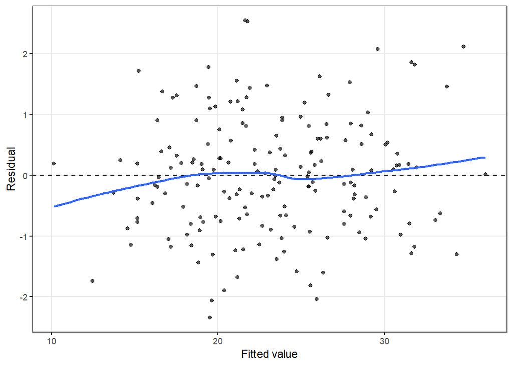

```r
if (exists("fit")) {
  mixed_plot(fit, type = "residuals")
}
```

Look for:

- nonlinear residual trend;
- funnel-shaped variance;
- clusters of extreme residuals;
- unexplained grouping pattern;
- serial or spatial dependence that requires a dedicated test or plot.

# 5 4. Singularity

A singular LMM has one or more random-effect dimensions estimated on or near a boundary. Common signs include a variance near zero or an extreme random-effect correlation.

A singular fit can mean:

- the data do not support the requested random structure;
- the design provides too little repeated information;
- a random slope is unnecessary;
- predictors are poorly scaled or nearly redundant.

It does **not** mean that the optimizer necessarily failed.

# 6 5. Create a deliberately demanding random structure

```r
if (requireNamespace("lme4", quietly = TRUE)) {
  z_sparse <- subset(z, time %in% c(0, 1, 5))
  demanding <- mixed_random_slopes(
    z_sparse,
    response = "height",
    fixed = "treatment * time",
    slope = "time",
    group = "subject",
    correlated = TRUE
  )
  mixed_diagnose(demanding)
}
```

```
#> $engine
#> [1] "lme4"
#>
#> $converged
#> [1] TRUE
#>
#> $convergence_messages
#> character(0)
#>
#> $singular
#> [1] FALSE
#>
#> $residuals
#>      fitted    residual
#> 1  16.56083  0.71372583
```

[output cut: 102 more lines]

This example is designed to encourage diagnosis, not to guarantee a singular fit on every backend version.

# 7 6. Simulation diagnostics for a count GLMM

```r
cnt <- mixed_data("counts")

if (requireNamespace("glmmTMB", quietly = TRUE)) {
  nb <- mixed_count(
    count ~ treatment * time + (1 | plot),
    data = cnt,
    family = "nbinom2"
  )
}
```

```r
if (
  exists("nb") &&
  requireNamespace("DHARMa", quietly = TRUE)
) {
  nb_diag <- mixed_diagnose(nb, simulate = TRUE, nsim = 500)
  nb_diag$simulation
}
```

```
#> Object of Class DHARMa with simulated residuals based on 500 simulations with refit = FALSE . See ?DHARMa::simulateResiduals for help.
#>
#> Scaled residual values: 0.6009355 0.2990035 0.1559889 0.6975702 0.5565368 0.6626475 0.06672819 0.8100045 0.2779629 0.302955 0.9715186 0.5195708 0.829097 0.04768862 0.1283551 0.7551486 0.1757995 0.008706832 0.3889101 0.2756478 ...
```

Simulation residuals are particularly helpful for detecting overdispersion, zero inflation, and nonuniform residual distributions in discrete models.

# 8 7. Influence by cluster

For `lme4` models, grouped deletion diagnostics can be requested through `influence.ME`.

```r
if (
  exists("fit") &&
  requireNamespace("influence.ME", quietly = TRUE)
) {
  infl <- mixed_influence(
    fit,
    group = "subject"
  )

  infl
}
```

```
#> $or.fixed
#>      (Intercept) treatmentT2     time treatmentT2:time
#> [1,]    16.83363    1.438112 2.019643        0.4899707
#>
#> $or.se
#>      (Intercept) treatmentT2      time treatmentT2:time
#> [1,]   0.7413319    1.048402 0.1545094        0.2185093
#>
#> $or.vcov
#>                  (Intercept) treatmentT2        time treatmentT2:time
#> (Intercept)       0.54957293 -0.54957293 -0.01395826       0.01395826
#> treatmentT2      -0.54957293  1.09914586  0.01395826      -0.02791652
#> time             -0.01395826  0.01395826  0.02387316      -0.02387316
#> treatmentT2:time  0.01395826 -0.02791652 -0.02387316       0.04774631
#>
#> $or.test
#>      (Intercept)      treatmentT2             time treatmentT2:time
#>        22.707283         1.371718        13.071328         2.242334
#>
#> $alt.fixed
#>     (Intercept) treatmentT2     time treatmentT2:time
#> S01    16.88879   1.3829570 1.980397        0.5292165
#> S02    16.92279   1.3489540 2.092688        0.4169257
#> S03    16.73654   1.5351999 1.962782        0.5468316
#> S04    16.93969   1.3320587 2.063973        0.4456406
#> S05    16.68489   1.5868532 1.980874        0.5287396
#> S06    17.08961   1.1821291 1.985519        0.5240948
#> S07    16.79783   1.4739102 2.062929        0.4466847
#> S08    16.59039   1.6813498 2.092289        0.4173251
#> S09    16.67992   1.5918233 2.002804        0.5068102
#> S10    17.36529   0.9064541 1.981960        0.5276535
#> S11    17.07416   1.1975793 1.954145        0.5554693
#> S12    16.61334   1.6584040 2.019838        0.4897762
#> S13    16.58147   1.6902713 1.979582        0.5300323
#> S14    16.90996   1.3617800 2.111095        0.3985186
#> S15    16.62979   1.6419501 2.023772        0.4858423
#> S16    16.83363   1.7281031 2.019643        0.4764474
#> S17    16.83363   1.4100335 2.019643        0.4806158
#> S18    16.83363   1.1444447 2.019643        0.5466959
#> S19    16.83363   1.6890868 2.019643        0.4646634
```

[output cut: 277 more lines]

```
#> S19    22.96615   1.6011329 12.92272         2.065774
#> S20    22.84037   1.5698298 12.92584         2.293302
#> S21    22.62357   1.1775133 12.86907         2.099701
#> S22    23.37824   1.0837559 12.85533         2.113752
#> S23    22.31550   1.3625614 12.84478         2.129001
#> S24    22.42354   1.2286353 12.89868         2.078702
#> S25    22.39495   1.4191338 13.39271         2.544779
#> S26    22.32030   1.2820304 12.83886         2.143121
#> S27    22.48200   1.4585683 12.85369         2.217592
#> S28    22.39379   1.2398875 12.89478         2.266178
#> S29    22.33870   1.3840272 12.85751         2.111187
#> S30    22.31110   1.2917170 13.24907         1.986481
#>
#> attr(,"class")
#> [1] "estex"
```

Influence means that removing a unit changes an estimate or inferential quantity materially. It is not the same as proving a data error.

# 9 8. Information criteria as descriptors

Fit two models under ML because their fixed-effect structures differ.

```r
if (requireNamespace("lme4", quietly = TRUE)) {
  m0_ml <- mixed_fit(
    height ~ time + (1 | subject),
    data = z,
    REML = FALSE
  )

  m1_ml <- mixed_fit(
    height ~ treatment + time + (1 | subject),
    data = z,
    REML = FALSE
  )
}
```

```r
if (exists("m0_ml") && exists("m1_ml")) {
  mixed_compare(
    no_treatment = m0_ml,
    treatment    = m1_ml,
    method       = "information"
  )
}
```

```
#>          model engine                     fixed npar    logLik      AIC
#> 1 no_treatment   lme4             height ~ time    4 -382.9747 773.9495
#> 2    treatment   lme4 height ~ treatment + time    5 -380.2232 770.4464
#>        BIC
#> 1 786.7213
#> 2 786.4111
```

AIC and BIC provide penalized likelihood descriptors. They do not know the experimental design or biological importance.

# 10 9. Likelihood-ratio test under ML

```r
if (exists("m0_ml") && exists("m1_ml")) {
  mixed_compare(
    m0_ml,
    m1_ml,
    method = "LRT"
  )
}
```

```
#> Data: ..mf_data
#> Models:
#> MODEL1: height ~ time + (1 | subject)
#> MODEL2: height ~ treatment + time + (1 | subject)
#>        npar    AIC    BIC  logLik -2*log(L)  Chisq Df Pr(>Chisq)
#> MODEL1    4 773.95 786.72 -382.97    765.95
#> MODEL2    5 770.45 786.41 -380.22    760.45 5.5031  1    0.01898 *
#> ---
#> Signif. codes:  0 '***' 0.001 '**' 0.01 '*' 0.05 '.' 0.1 ' ' 1
```

When fixed effects differ, the package blocks this LRT if an `lmer` model is still fitted by REML.

# 11 10. Deliberate invalid comparison

```r
m0_reml <- mixed_fit(height ~ time + (1 | subject), z, REML = TRUE)
m1_reml <- mixed_fit(height ~ treatment + time + (1 | subject), z, REML = TRUE)
mixed_compare(m0_reml, m1_reml, method = "LRT")
```

This chunk is deliberately not evaluated because it is intended to show a safeguarded error.

# 12 11. Kenward-Roger comparison

Fit two nested LMMs under the conventional REML setting.

```r
if (requireNamespace("lme4", quietly = TRUE)) {
  kr_small <- mixed_fit(
    height ~ time + (1 | subject),
    data = z
  )

  kr_large <- mixed_fit(
    height ~ treatment + time + (1 | subject),
    data = z
  )
}
```

```r
if (
  exists("kr_small") && exists("kr_large") &&
  requireNamespace("pbkrtest", quietly = TRUE)
) {
  mixed_compare(
    kr_small,
    kr_large,
    method = "Kenward-Roger"
  )
}
```

```
#> large : height ~ treatment + time + (1 | subject)
#> small : height ~ time + (1 | subject)
#>          stat     ndf     ddf F.scaling p.value
#> Ftest  5.6375  1.0000 28.0000         1 0.02467 *
#> ---
#> Signif. codes:  0 '***' 0.001 '**' 0.01 '*' 0.05 '.' 0.1 ' ' 1
```

Kenward-Roger adjusts the small-sample reference distribution and covariance estimation for fixed-effect testing in appropriate Gaussian LMM settings.

# 13 12. Parametric-bootstrap comparison

Use a small simulation count for vignette execution.

```r
if (
  exists("kr_small") && exists("kr_large") &&
  requireNamespace("pbkrtest", quietly = TRUE)
) {
  pb_demo <- mixed_compare(
    kr_small,
    kr_large,
    method = "parametric-bootstrap",
    nsim = 99,
    seed = 260818
  )

  pb_demo
}
```

```
#> Bootstrap test; time: 2.78 sec; samples: 99; extremes: 0;
#> large : height ~ treatment + time + (1 | subject)
#>          stat df p.value
#> LRT    5.5031  1 0.01898 *
#> PBtest 5.5031    0.01000 **
#> ---
#> Signif. codes:  0 '***' 0.001 '**' 0.01 '*' 0.05 '.' 0.1 ' ' 1
```

Production-scale example:

```r
pb_full <- mixed_compare(
  kr_small,
  kr_large,
  method = "parametric-bootstrap",
  nsim = 4999,
  seed = 260818
)
```

The production chunk is not evaluated during vignette build because thousands of refits are intentionally expensive.

# 14 13. Compare covariance candidates separately

```r
if (requireNamespace("nlme", quietly = TRUE)) {
  ar1 <- mixed_ar1(z, "height", "treatment*time", "time", "subject")
  car1 <- mixed_car1(z, "height", "treatment*time", "time", "subject")
}
```

```r
if (exists("ar1") && exists("car1")) {
  mixed_covariance_compare(
    AR1 = ar1,
    CAR1 = car1
  )
}
```

```
#>   model engine      AIC      BIC    logLik
#> 1   AR1   nlme 715.9959 738.1893 -350.9979
#> 2  CAR1   nlme 715.9959 738.1893 -350.9979
```

The fixed mean model should be kept comparable while evaluating covariance structure.

# 15 14. A model-comparison decision tree

Use the following logic.

**Question A: Are fixed effects different?**

- For `lmer` likelihood-ratio comparison, fit under ML.
- For small-sample Gaussian LMM inference, consider Kenward-Roger or parametric bootstrap when appropriate.

**Question B: Are random or covariance structures different?**

- Keep the scientific fixed-effect estimand comparable.
- Use likelihood descriptors and diagnostics.
- Prefer structures supported by the design and repeated-measure geometry.

**Question C: Are model families different?**

- Diagnose distributional adequacy.
- Compare predictive implications and biological process assumptions.
- Do not rely on a single criterion.

# 16 15. Diagnostic table output

```r
if (exists("diag")) {
  mixed_table(
    diag,
    component = "diagnostics",
    format = "markdown",
    caption = "Mixed-model diagnostic summary"
  )
}
```

Mixed-model diagnostic summary

| engine | converged | singular | message |
| --- | --- | --- | --- |
| lme4 | TRUE | FALSE |  |

# 17 16. What not to do

Avoid workflows such as:

1. generate ten random structures;
2. rank by AIC;
3. keep the minimum;
4. ignore convergence warnings;
5. report only the final p-values.

This process disconnects modeling from experimental design and understates selection uncertainty.

# 18 17. Practice exercises

1. Fit random-intercept and random-slope models with the same fixed effects. Compare their diagnostics before AIC.
2. Fit Poisson and negative-binomial count models. Ask whether the more flexible distribution solves a residual problem.
3. Compare AR(1) and heterogeneous AR(1) models. State the additional scientific assumption introduced by heterogeneous residual variances.
4. Refit a fixed-effect comparison under REML and verify that the guarded LRT refuses the invalid comparison.

# 19 18. Reporting checklist

For every model comparison, report:

- models being compared;
- what differs between them;
- fitting method;
- comparison method;
- diagnostic status;
- rationale for the preferred representation;
- whether substantive conclusions are stable.

# 20 19. Key take-home messages

- Diagnostics precede model ranking.
- Convergence and singularity are different concepts.
- Information criteria are descriptors, not scientific decision rules.
- Fixed-effect LRTs with `lmer` require appropriate ML fitting when the fixed structure changes.
- Influence identifies sensitivity, not automatically erroneous observations.
- Small-sample methods answer specific inferential questions and do not replace design reasoning.

# 21 20. Next vignette

Continue with `06-robust-sensitivity.Rmd` for robust estimation, contamination screens, and cluster-robust covariance.